# 9 Comparison of PURA targets RNAs enriched in dendrites or cytoplasmic granules

Melina

28 July, 2022

# 1 What was done?

- Overlap of PURA bound to dendritic RNAs from 6 indipendent RNAseqs of mice dendrites

# 2 Input

```r
# binding sites
BS <- readRDS("/Users/melinaklostermann/Documents/projects/PURA/Molitor-et-al-2022/binding_sites_characterized.rds")

# deseq analysis from PURA knockdown
res_RNAseq <- readRDS("/Users/melinaklostermann/Documents/projects/PURA/Molitor-et-al-2022/deseq.rds")
HeLa_expression <- filter(res_RNAseq, baseMean > 0)
rnaseq_counts <- readRDS("/Users/melinaklostermann/Documents/projects/PURA/Molitor-et-al-2022/rnaseq_counts.rds")

# dendritic RNAs
dendritic_RNAs <- readxl::read_xlsx("/Users/melinaklostermann/Documents/projects/PURA/02_R_new_pip/07-Localisation/02-DendriticRNAs/12915_2019_630_MOESM6_ESM.xlsx", sheet = 1)

# p-body transcriptome
pb_transcriptome <- readxl::read_xlsx("/Users/melinaklostermann/Documents/projects/PublicData/p-body/1-s2.0-S1097276517306512-mmc3.xlsx")
# stress granule transcriptome
sg_transcriptome <- readxl::read_xlsx("/Users/melinaklostermann/Documents/projects/PublicData/Stress_granule/1-s2.0-S1097276517307906-mmc2.xlsx")
```

```r
# helper functions
give.n <- function(x){
  return(c(y = max(x)*1.1, label = length(x)))
  # experiment with the multiplier to find the perfect position
}

gg_n <-   stat_summary(fun.data = give.n, geom = "text", fun.y = max,
                   position = position_dodge(width = 0.75))
```

# 3 Dendritic RNAs

## 3.1 Studies identifying dendritic RNAs

- There are several studies identifying dendritic RNAs, by performing RNAseq on dendrites (in mice!)
- The study of Middleton et. al 2019 (doi:10.1186/s12915-019-0630-z) offers a list of dendritic RNAs found in 6 different studies.
- We can use genes discribed in 3 or 4 studies as a strong set of dendritic RNAs.
- Here I overlap iCLIP binding sites and RNAseq changing RNAs with dendritic RNAs to suggest some whos dendritic localisation might be influenced by PURA (as a transport factor). Some can be tested for their localisation in neuronal precursors in fish experiments with and without a PURA knockdown.

## 3.2 Find human orthologs to mouse genes

```r
############
# translate mouse genes to human genes with ortology 1-2-1
#############
ensembl38p13 <- useMart(biomart='ENSEMBL_MART_ENSEMBL',
                        dataset='hsapiens_gene_ensembl')

my_attributes <- c("ensembl_gene_id", "mmusculus_homolog_ensembl_gene", "mmusculus_homolog_associated_gene_name", "mmusculus_homolog_orthology_type", "external_gene_name")

info_biomart_new <- getBM(attributes=my_attributes,
                        # filters = "mmusculus_homolog_ensembl_gene",
                        # values = dendritic_RNAs$GeneName,
                        mart = ensembl38p13, useCache = F)


dendritic_RNAs <- left_join(dendritic_RNAs, info_biomart_new, by = c(GeneName = "mmusculus_homolog_associated_gene_name")) #%>% dplyr::filter(., mmusculus_homolog_orthology_type == "ortholog_one2one")
# save(dendritic_RNAs, file = paste0(outpath, "dendritic_RNAs_with_human_ortholog_one2one.RData"))

HeLa_expression <- left_join(HeLa_expression, info_biomart_new, by = c(gene_id = "ensembl_gene_id")) #%>% dplyr::filter(., mmusculus_homolog_orthology_type == "ortholog_one2one")
# save(HeLa_expression, file = paste0(outpath, "HeLA_RNAs_with_mouse_ortholog_one2one.RData"))
```

## 3.3 How many genes can be compared between mouse dendrites and HeLa cells?

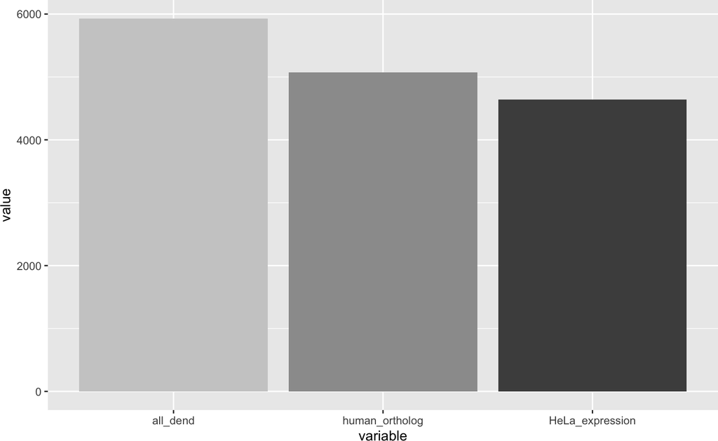

```r
# add expression
dendritic_RNAs <- mutate(dendritic_RNAs, HeLa_expressed = case_when(
  (ensembl_gene_id %in% HeLa_expression$ensembl_gene_id) & (mmusculus_homolog_orthology_type == "ortholog_one2one") ~ "HeLa_expressed",
                                                                     T ~ "not_HeLa_expressed"))



###################
# plot dendritic perspective
##################

dend_df <- data.frame( all_dend = rep(T,nrow(dendritic_RNAs))) %>%
  mutate(human_ortholog = case_when(dendritic_RNAs$mmusculus_homolog_orthology_type == "ortholog_one2one" ~ T, T ~ F ),
         HeLa_expression = case_when(dendritic_RNAs$HeLa_expressed == "HeLa_expressed" ~ T, T~ F ))
dend_df <- colSums(dend_df) %>% reshape2::melt(.)
dend_df$variable <- factor(rownames(dend_df), levels =  rownames(dend_df))

ggplot(dend_df)+
  geom_col(aes(x = variable, y = value, fill = variable), position = "dodge")+
   scale_fill_grey(start=0.8, end=0.3)+
  theme(legend.position = "none")
```

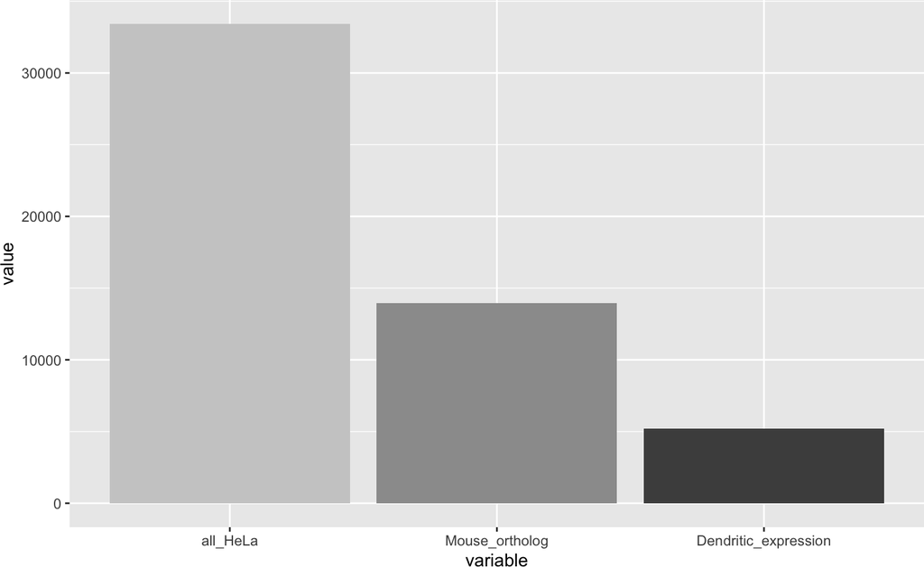

```r
# ggsave(paste0(outpath, "dendritic_to_HeLa_RNAs.pdf"), width = 3, height = 6, units = "cm")


###################
# HeLa perspective
##################

hela_df <- data.frame( all_HeLa= rep(T,nrow(HeLa_expression))) %>%
  mutate(Mouse_ortholog = case_when(HeLa_expression$mmusculus_homolog_orthology_type == "ortholog_one2one" ~ T, T ~ F ),
          Dendritic_expression = case_when(HeLa_expression$ensembl_gene_id %in% dendritic_RNAs$ensembl_gene_id ~ T, T~ F ))
hela_df <- colSums(hela_df) %>% reshape2::melt(.)
hela_df$variable <- factor(rownames(hela_df), levels =  rownames(hela_df))

ggplot(hela_df)+
  geom_col(aes(x = variable, y = value, fill = variable), position = "dodge")+
   scale_fill_grey(start=0.8, end=0.3)+
  theme(legend.position = "none")
```

```r
# ggsave(paste0(outpath, "HeLa_to_dendritic_RNAs.pdf"), width = 3, height = 6, units = "cm")
```

## 3.4 PURA binding in dendritic cells

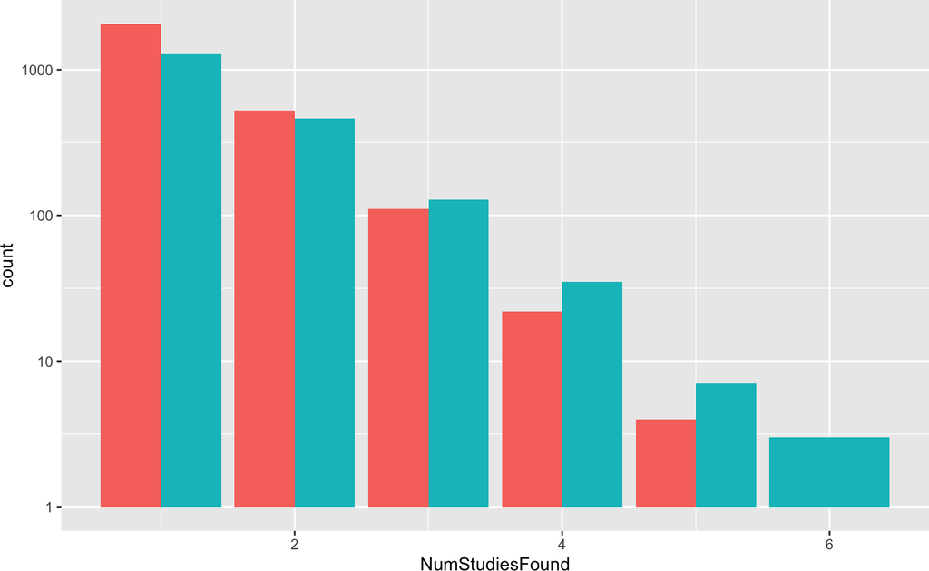

```r
dendritic_RNAs <- mutate(dendritic_RNAs, bound = case_when(
  ensembl_gene_id %in% BS$gene_id ~ "PURA-bound",
  T ~ "No binding"
) )


##################
# plot num studies perspective
###################
df_hela <- dendritic_RNAs %>% filter((HeLa_expressed == "HeLa_expressed") & (mmusculus_homolog_orthology_type == "ortholog_one2one"))

ggplot(df_hela, aes(x = NumStudiesFound, fill = bound))+
  geom_bar(position = "dodge")+
  scale_y_log10()+
  theme(legend.position = "none")
```

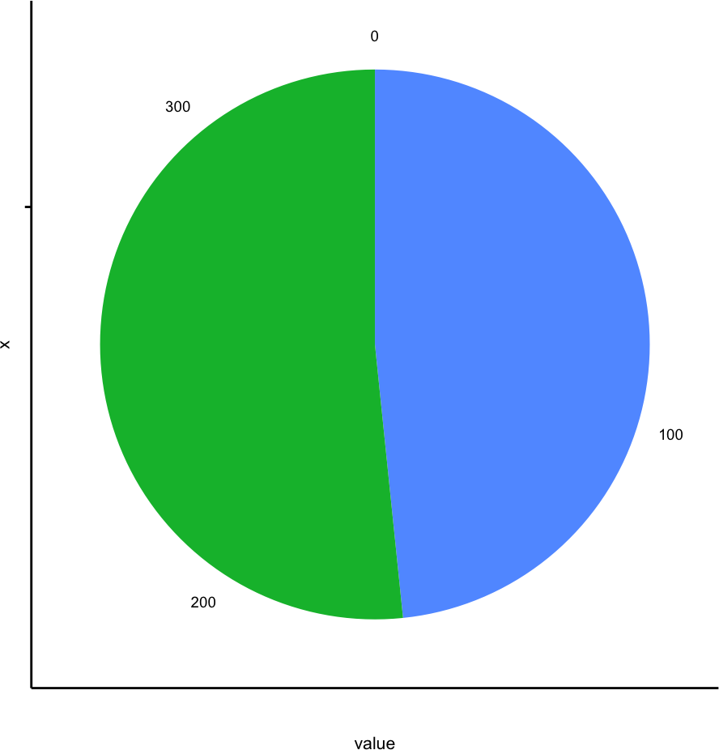

```r
# ggsave(paste0(outpath, "dendritic_binding_HeLa.pdf"), width = 6, height = 6, units = "cm")

########################
# plot pie visualisation
########################

# get reproducible found dendritic RNAs
repro_cut  = 3
repro_dendritic_RNAs <- dendritic_RNAs %>% filter((NumStudiesFound >= repro_cut) & mmusculus_homolog_orthology_type == "ortholog_one2one")

# calculate overlaps
venn_df <- data.frame( bound_dend_HeLa = repro_dendritic_RNAs$bound == "PURA-bound",
                       repro_dendritic_RNAs = T)

venn_fit <- eulerr::euler(venn_df)


# make pie chart
gg_df <- venn_fit$original.values %>% reshape2::melt()
gg_df$group = rownames(gg_df)

ggplot(gg_df, aes( x ="", y=value, fill = group))+
  geom_bar(stat="identity", width=1) +
  coord_polar("y", start=0)+
  theme_paper()+
  theme(legend.position =  "None")
```

```r
#ggsave(paste0(outpath, "dendritic_pie.pdf"), width = 5, height = 5, units = "cm")
```

# 4 Cytoplasmic granules

- pb: p-bodies
- sg: stress granules
- the studies from Hubstenberger et al and Khong et al performed RNAseq of pbs or sg vs whole cell extracts and then calculate foldChanges of granule vs whole cell
- we treat RNAs with a foldchange > 0 and a p-value < 0.01 from these studies as enricht in the granule
- granule enriched RNA is then overlapped with PURA-binding and compared to PURA kd foldchanges

## 4.1 Overlap of pb and sg enriched RNAs with PURA bound RNAs

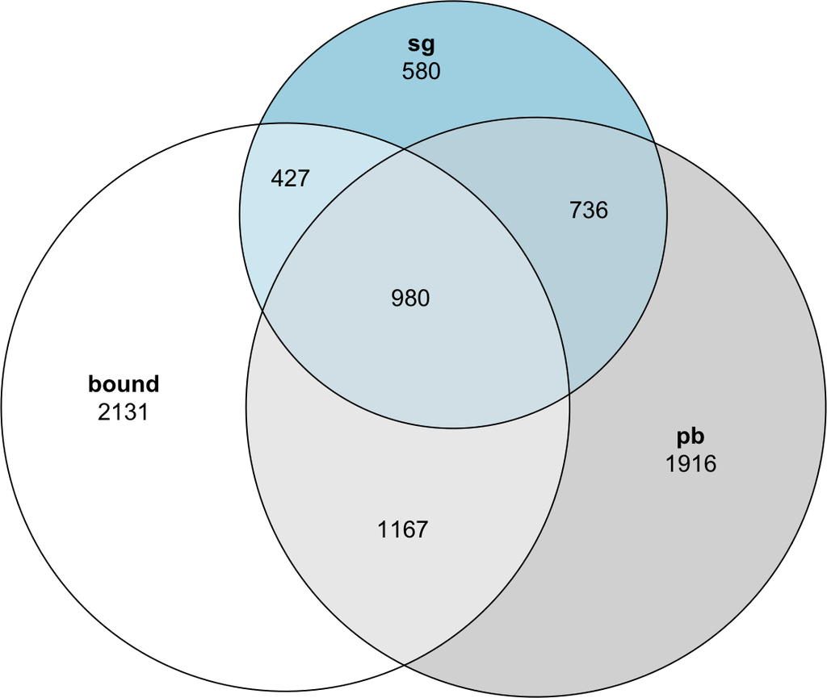

```r
# rename tables
pb_transcriptome <- mutate(pb_transcriptome, l2fc = as.numeric(`RNA enrichment in P-body (log2) (Fold change=sorted P-bodies/pre-sorted fraction)`), pfdr = as.numeric(`adjusted p-value (FDR) of RNA enrichment`)  )
sg_transcriptome <- sg_transcriptome %>% mutate(l2fc = log2(`Fold change`))


# get pb_transcriptome and sg_transcriptome tpms from our HeLa RNAseq
tpms <- rnaseq_counts[, c("gene_id", "mean_tpm_rnaseq")]
tpms <- filter(tpms, mean_tpm_rnaseq > 0)

pb_transcriptome_expr <- pb_transcriptome[pb_transcriptome$`Ensembl Gene ID` %in% tpms$gene_id,]
sg_transcriptome_expr <- sg_transcriptome[sg_transcriptome$test_id %in% tpms$gene_id,]

pb_transcriptome_expr <- pb_transcriptome_expr %>% left_join(tpms, by= c(`Ensembl Gene ID` = "gene_id"))
sg_transcriptome_expr <- sg_transcriptome_expr %>% left_join(tpms, by= c(test_id = "gene_id"))

# enriched granule RNAs
pb_up_transcriptome <- pb_transcriptome_expr[pb_transcriptome_expr$l2fc > 0 & pb_transcriptome_expr$pfdr < 0.01,]
sg_up_transcriptome <- sg_transcriptome_expr[sg_transcriptome_expr$l2fc > 0 & sg_transcriptome_expr$p_value < 0.01, ]

# bound RNAs enriched in granules
bound_pb_transcriptome <- pb_up_transcriptome[pb_up_transcriptome$`Ensembl Gene ID` %in% substr(BS$gene_id,1,15),]
bound_sg_transcriptome <- sg_up_transcriptome[sg_up_transcriptome$test_id %in% substr(BS$gene_id,1,15),]

# RNAs enriched in both granule types
bound_sg_pb <- bound_pb_transcriptome[bound_pb_transcriptome$`Ensembl Gene ID` %in% bound_sg_transcriptome$test_id, ]
sg_pb<-  pb_up_transcriptome[pb_up_transcriptome$`Ensembl Gene ID` %in% sg_up_transcriptome$test_id, ]

# venn of overlaps
all_genes <- c(pb_up_transcriptome$`Ensembl Gene ID`, sg_up_transcriptome$test_id, BS$gene_id) %>% substr(., 1, 15) %>% unique(.)
overlaps2 <- data.frame( bound = all_genes %in% substr(BS$gene_id,1,15),
                         pb = all_genes %in% pb_up_transcriptome$`Ensembl Gene ID`,
                         sg = all_genes %in% sg_up_transcriptome$test_id)


venn <- eulerr::euler(overlaps2)
plot(venn, quantities = TRUE, shape = "ellipse", fontface = 1)
```

## 4.2 Compare PURA-binding and p-body/stress granule enrichment

### 4.2.1 In tpm bins

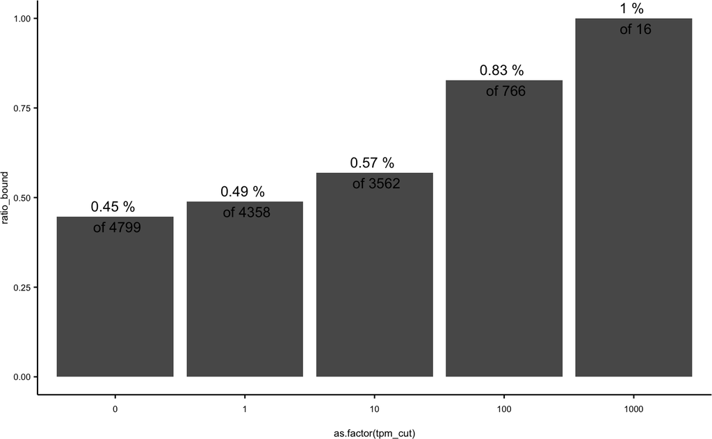

```r
#######################
# pb overlap per tpm
#######################
# tpm distribution comp
pb_up_transcriptome <- mutate(pb_up_transcriptome, bound = case_when(
  `Ensembl Gene ID` %in% substr(BS$gene_id,1,15) ~ T,
  T~F
))

s <- list(0,1,10,100,1000)

pb_up_transcriptome_tpm_cutoffs <- map(s, ~pb_up_transcriptome %>% filter(mean_tpm_rnaseq > .x))

pb_up_transcriptome_tpm_cutoffs_bound <- map2_dfr(pb_up_transcriptome_tpm_cutoffs, s, ~c(bound = nrow(.x[.x$`Ensembl Gene ID` %in% substr(BS$gene_id,1,15),]),
                                                  all_over_tpm_cut =   nrow(.x),
                                                  tpm_cut = .y))


pb_tpm_cutoffs_bound <- mutate(pb_up_transcriptome_tpm_cutoffs_bound, ratio_bound = bound / all_over_tpm_cut)

ggplot(pb_tpm_cutoffs_bound, aes(x = as.factor(tpm_cut), y = ratio_bound, label = all_over_tpm_cut))+
  geom_col(position = "identity")+
  geom_text(aes(label=paste(round(ratio_bound,2), "% \n of", all_over_tpm_cut)),
             geom="text", color= "black", size=4)+
  #ggrepel::geom_text_repel()+
  ylim(0,1)+
  theme_paper()
```

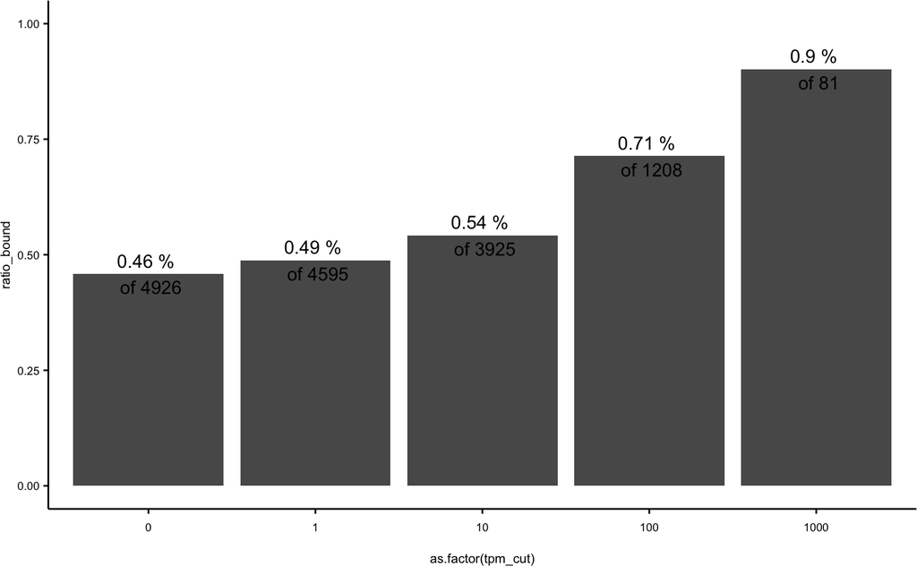

```r
#ggsave(paste0(outpath, "pb_and_binding_vs_tpm.pdf"), width = 5 , height  = 5, units = "cm")


#######################
# sg overlap per tpm
#######################
# tpm distribution comp
sg_transcriptome_expr <- mutate(sg_transcriptome_expr, bound = case_when(
  test_id %in% substr(BS$gene_id,1,15) ~ T,
  T~F
))


sg_transcriptome_up <- sg_transcriptome_expr %>% filter(`Fold change`>0 & q_value < 0.01)

s <- list(0,1,10,100,1000)

sg_transcriptome_up_tpm_cutoffs <- map(s, ~sg_transcriptome_up %>% filter(mean_tpm_rnaseq > .x))

sg_transcriptome_up_tpm_cutoffs_bound <- map2_dfr(sg_transcriptome_up_tpm_cutoffs, s, ~c(bound = nrow(.x[.x$test_id %in% substr(BS$gene_id,1,15),]),
                                                  all_over_tpm_cut =   nrow(.x),
                                                  tpm_cut = .y))



sg_tpm_cutoffs_bound <- mutate(sg_transcriptome_up_tpm_cutoffs_bound, ratio_bound = bound / all_over_tpm_cut)

ggplot(sg_tpm_cutoffs_bound, aes(x = as.factor(tpm_cut), y = ratio_bound, label = all_over_tpm_cut))+
  geom_col(position = "identity")+
  geom_text(aes(label=paste(round(ratio_bound,2), "% \n of", all_over_tpm_cut)),
             geom="text", color= "black", size=4)+
  #ggrepel::geom_text_repel()+
  ylim(0,1)+
  theme_paper()
```

```r
#ggsave(paste0(outpath, "sg_and_binding_vs_tpm.pdf"), width = 5 , height  = 5, units = "cm")
```

### 4.2.2 adjust control group for expression

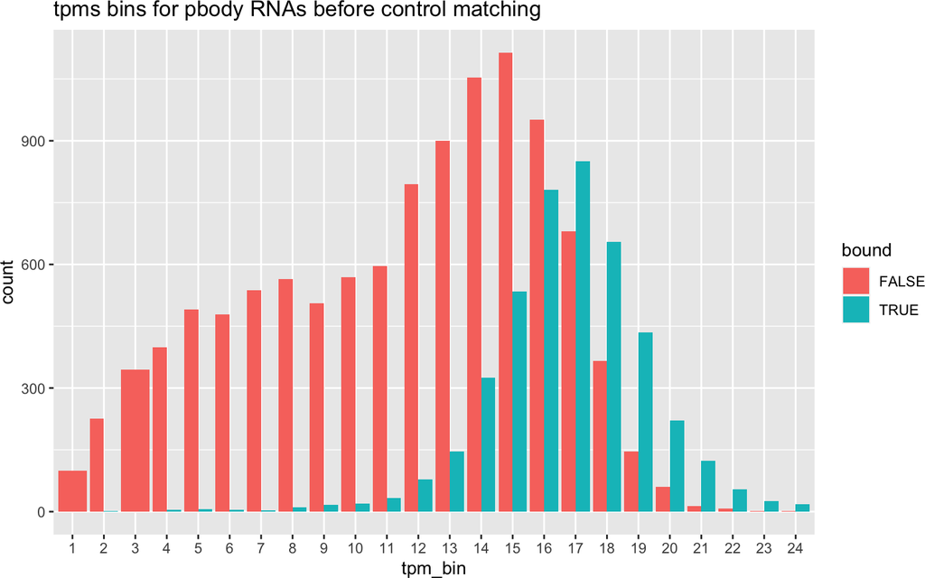

```r
########################
# pb expression controlled negative set
#######################
# introduce tpm bins
pb_transcriptome_expr <- mutate(pb_transcriptome_expr,
                                bound = `Ensembl Gene ID` %in% BS$gene_id,
                                tpm_bin = cut(log10(mean_tpm_rnaseq),
                   breaks=c(-Inf, seq(-2, 3.5, 0.25), Inf),
                   labels=c(1:24)))

ggplot(pb_transcriptome_expr, aes(x = tpm_bin, fill = bound))+
  geom_bar(position = "dodge")+
  ggtitle("tpms bins for pbody RNAs before control matching")
```

```r
# get distribution of bound genes over tpm bins
bound_bin_distr <- table(pb_transcriptome_expr[pb_transcriptome_expr$bound == T, ]$tpm_bin) %>% as.list()

# get the same amount of random non bound genes per tpm bin
set.seed(42)
unbound_binned_list <- pb_transcriptome_expr[pb_transcriptome_expr$bound == F, ] %>% group_split(tpm_bin, .keep = T)
unbound_matched <- map2(unbound_binned_list, bound_bin_distr, ~.x[sample(1:nrow(.x), size = min(c(nrow(.x), .y))),]) %>% map_dfr(~.x)

# fill up unbound to same n with genes from lower tpm bins
n_bound <- sum(unlist(bound_bin_distr))
n_unbound <- nrow(unbound_matched)
n_missing <- n_bound - n_unbound
n_missing
```

```
## [1] 1107
```

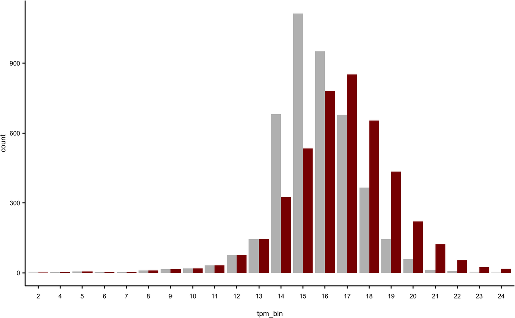

```r
# get genes not in unbound matched set
unbound_left <- pb_transcriptome_expr[pb_transcriptome_expr$bound == F, ] %>% .[!(.$`Ensembl Gene ID` %in% unbound_matched$`Ensembl Gene ID` ),]
unbound_fill <- arrange(unbound_left, desc(mean_tpm_rnaseq)) %>% .[1:n_missing,]

pb_transcr_bound_unbound_matched <- rbind(pb_transcriptome_expr[pb_transcriptome_expr$bound == T, ], unbound_matched, unbound_fill )

ggplot(pb_transcr_bound_unbound_matched, aes(x = tpm_bin, fill = bound))+
  geom_bar(position = "dodge")+
  #ggtitle("tpms bins for pbody RNAs after control matching")+
  scale_fill_manual(values =  c("grey", "darkred"))+
  #ggtitle("pbody enrichment in relation to BS site", subtitle = "NA = matched control")+
  theme_paper()+
   theme(legend.position = "None")
```

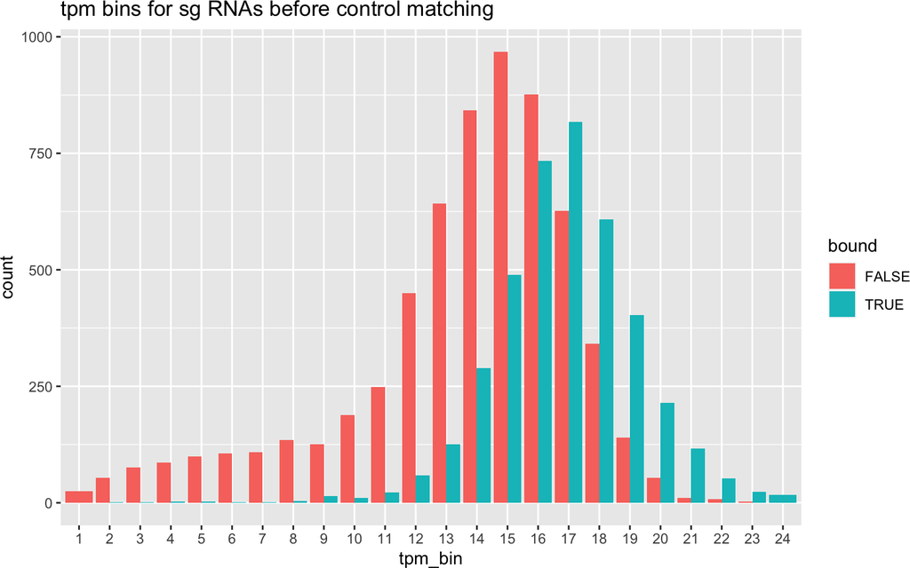

```r
########################
# sg expression controlled negative set
#######################
# introduce tpm bins
sg_transcriptome_expr <- mutate(sg_transcriptome_expr,
                                bound = test_id %in% BS$gene_id,
                                  tpm_bin = cut(log10(mean_tpm_rnaseq),
                   breaks=c(-Inf, seq(-2, 3.5, 0.25), Inf),
                   labels=c(1:24)))

ggplot(sg_transcriptome_expr, aes(x = tpm_bin, fill = bound))+
  geom_bar(position = "dodge")+
  ggtitle("tpm bins for sg RNAs before control matching")
```

```r
# get distribution of bound genes over tpm bins
bound_bin_distr <- table(sg_transcriptome_expr[sg_transcriptome_expr$bound == T, ]$tpm_bin) %>% as.list()

# get the same amount of random non bound genes per tpm bin
set.seed(42)
unbound_binned_list <- sg_transcriptome_expr[sg_transcriptome_expr$bound == F, ] %>% group_split(tpm_bin, .keep = T)
unbound_matched <- map2(unbound_binned_list, bound_bin_distr[-1], ~.x[sample(1:nrow(.x), size = min(c(nrow(.x), .y))),]) %>% map_dfr(~.x)

# fill up unbound to same n with genes from lower tpm bins
n_bound <- sum(unlist(bound_bin_distr))
n_unbound <- nrow(unbound_matched)
n_missing <- n_bound - n_unbound
n_missing
```

```
## [1] 270
```

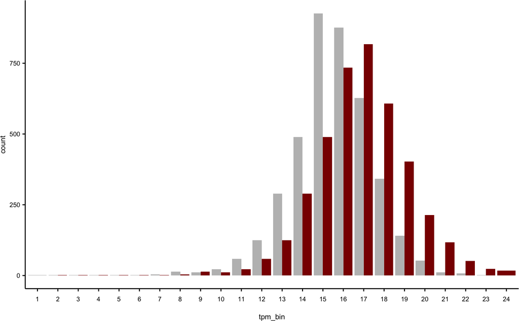

```r
# get genes not in unbound matched set
unbound_left <- sg_transcriptome_expr[sg_transcriptome_expr$bound == F, ] %>% .[!(.$test_id %in% unbound_matched$test_id ),]
unbound_fill <- arrange(unbound_left, desc(mean_tpm_rnaseq)) %>% .[1:n_missing,]

sg_transcr_bound_unbound_matched <- rbind(sg_transcriptome_expr[sg_transcriptome_expr$bound == T, ], unbound_matched, unbound_fill )

ggplot(sg_transcr_bound_unbound_matched, aes(x = tpm_bin, fill = bound))+
  geom_bar(position = "dodge")+
  #ggtitle("tpm bins for sg RNAs before control matching")+
  scale_fill_manual(values =  c("grey", "darkred"))+
  #ggtitle("pbody enrichment in relation to BS site", subtitle = "NA = matched control")+
  theme_paper()+
   theme(legend.position = "None")
```

### 4.2.3 Compare enrichment to binding

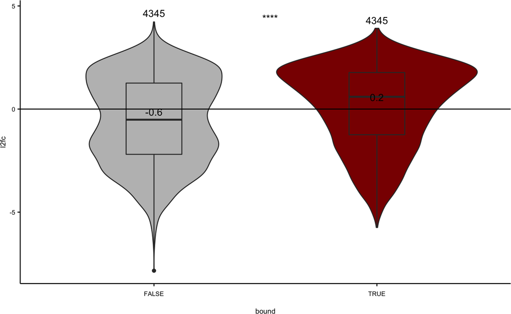

```r
# Comparison pb
ggplot(pb_transcr_bound_unbound_matched, aes(y=l2fc, x = bound, fill = bound))+
  geom_violin()+
  geom_boxplot(width = 0.25)+
  gg_n +
  stat_summary(fun.y=mean, geom="text", show_guide = FALSE,
               vjust=-0.7, aes( label=round(..y.., digits=1)))+
    stat_compare_means(aes(label = ..p.signif..), label.x = 1.5)+
  scale_fill_manual(values =  c("grey", "darkred"))+
  geom_hline(yintercept = 0)+
  #ggtitle("pbody enrichment in relation to BS site", subtitle = "NA = matched control")+
  theme_paper()+
  theme(legend.position = "None")
```

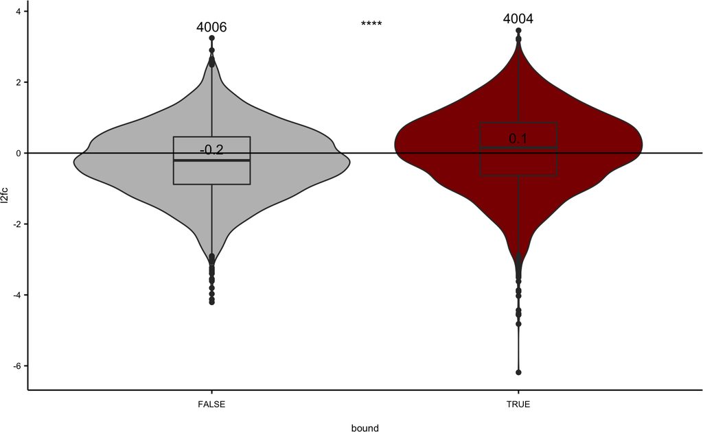

```r
# Comparison SG
ggplot(sg_transcr_bound_unbound_matched, aes(y=l2fc, x = bound, fill = bound))+
  geom_violin()+
  geom_boxplot(width = 0.25)+
  gg_n +
  stat_summary(fun.y=mean, geom="text", show_guide = FALSE,
               vjust=-0.7, aes( label=round(..y.., digits=1)))+
    stat_compare_means(aes(label = ..p.signif..), label.x = 1.5)+
  scale_fill_manual(values =  c("grey", "darkred"))+
  geom_hline(yintercept = 0)+
  #ggtitle("pbody enrichment in relation to BS site", subtitle = "NA = matched control")+
  theme_paper()+
  theme(legend.position = "None")
```

## 4.3 Comparison of granule localisation to PURA kd RNA changes

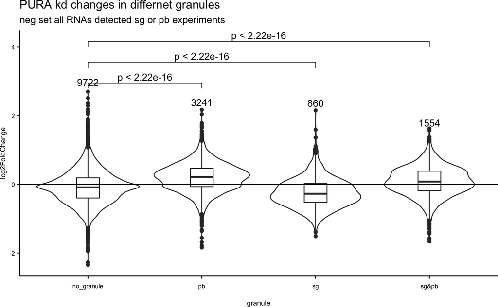

```r
# get most importanat info from both granules
sg_info <- sg_transcriptome_expr[,c("test_id", "l2fc", "q_value")]
colnames(sg_info) <- c("gene_id", "l2fc.sg", "fdr.sg")
sg_info_2  <- sg_info %>% filter(l2fc.sg >0 , fdr.sg < 0.01 )

pb_info <- pb_transcriptome_expr[, c("Ensembl Gene ID", "l2fc", "pfdr")]
colnames(pb_info) <- c("gene_id", "l2fc.pb", "fdr.pb")
pb_info_2  <- pb_info %>% filter(l2fc.pb >0 , fdr.pb < 0.01 )


# add PURA kd full
granules_2 <- full_join(sg_info, pb_info, by = "gene_id") %>%
  left_join(.,res_RNAseq, by = c(gene_id = "ensembl_gene_id")) %>%
  mutate(granule = case_when((l2fc.pb > 0 & l2fc.sg > 0 & fdr.sg < 0.01 & fdr.pb <0.01)  ~ "sg&pb",
                             (l2fc.pb > 0 & fdr.pb < 0.01)  ~ "pb",
                             (l2fc.sg > 0 & fdr.sg < 0.01 )  ~ "sg",
                             T ~ "no_granule"))

my_comparisons <- list(c("no_granule", "pb"), c("no_granule", "sg"), c("no_granule", "sg&pb"))

#plot
ggplot(granules_2, aes(x = granule, y = log2FoldChange))+
  geom_violin()+
  geom_boxplot(width=0.2)+
   gg_n +
  geom_hline(yintercept = 0)+
  theme_paper()+
    stat_compare_means(comparisons = my_comparisons)+
  ggtitle("PURA kd changes in differnet granules", subtitle = "neg set all RNAs detected sg or pb experiments")
```